# Project Topic

This project is about if, after the COVID-19 pandemic, people prefer working from home or working from the office. This data set is survey data tabulated to determine whether people prefer working from home and do the demographics of these people surveyed impact their preference. The ages, occupation, gender, whether they have kids or not, and where their office is located inside their residence are features that are documented. Some of the questions asked are whether they though staying home saved money, improved sleep, increased or decreased productivity, or improved work/life balance.

The machine learning task I will be using is classification to be able to determine which groups of people would rather work from home or work in office and what benefits or detriments it provided.

### Project Goal

My goal for this project is to determine if there are any benefits to working from home compared to working in the office. Or if there are any downfalls to working from home. This is important because after the COVID-19 pandemic the amount of people working from home increased by a large amount. In 2023 companies are now discussing returning back to the office or doing a hybrid work environment where some work days are in office and some are from home. With this push to return back to office will there be a loss of benefits that people were reeping when they worked from home?

### Data

This data set is survey data from kaggle. Hardly any machine learning tasks or data analysis has been done on this data set so there is a lot of information that can be discovered. A bit about the specifics of the data set is discussed in the project topic. Citation: anninasimon. (n.d.). Predict If People Prefer WFH Versus WFO Data. Retrieved from https://www.kaggle.com/datasets/anninasimon/predict-if-people-prefer-wfh-verses-wfo-data

### Importing the data and data description

```python
# importing necessary libraries
import numpy as np   #Linear algera Library
import pandas as pd
import matplotlib.pyplot as plt  #to plot graphs
import seaborn as sns
from sklearn.model_selection import train_test_split
from sklearn.linear_model import LogisticRegression
from sklearn.metrics import classification_report,confusion_matrix
import math
from sklearn import metrics
from sklearn.neighbors import KNeighborsClassifier
from sklearn.model_selection import train_test_split, GridSearchCV
from sklearn.metrics import accuracy_score
```

```python
# uploading data
data = pd.read_csv("WFH_WFO_dataset.csv")
```

```python
# visual inspection of data
data.head()
```

|  | ID | Name | Age | Occupation | Gender | Same_ofiice_home_location | kids | RM_save_money | RM_quality_time | RM_better_sleep | calmer_stressed | RM_professional_growth | RM_lazy | RM_productive | digital_connect_sufficient | RM_better_work_life_balance | RM_improved_skillset | RM_job_opportunities | Target |
| --- | --- | --- | --- | --- | --- | --- | --- | --- | --- | --- | --- | --- | --- | --- | --- | --- | --- | --- | --- |
| 0 | 1 | Bhavana | 45 | Tutor | Female | Yes | Yes | Yes | Yes | Yes | CALMER | 5 | 1 | 5 | Yes | 5 | 5 | Yes | 1 |
| 1 | 2 | Harry | 24 | Tutor | Male | No | No | No | No | No | CALMER | 2 | 2 | 2 | No | 3 | 3 | No | 1 |
| 2 | 3 | Banditaa | 53 | HR | Female | Yes | Yes | Yes | Yes | Yes | CALMER | 3 | 3 | 4 | No | 5 | 3 | No | 1 |
| 3 | 4 | Neetha | 26 | Engineer | Female | Yes | No | Yes | Yes | No | STRESSED | 3 | 4 | 4 | No | 4 | 5 | Yes | 0 |
| 4 | 5 | Ram | 26 | Recruiter | Male | Yes | No | No | Yes | No | STRESSED | 3 | 3 | 5 | Yes | 4 | 2 | Yes | 1 |

```python
# description of data
print(len(data))
print(data.columns)
print(len(data.columns))
print(data.dtypes)
```

```
207
Index(['ID', 'Name', 'Age', 'Occupation', 'Gender',
       'Same_ofiice_home_location', 'kids', 'RM_save_money', 'RM_quality_time',
       'RM_better_sleep', 'calmer_stressed', 'RM_professional_growth',
       'RM_lazy', 'RM_productive', 'digital_connect_sufficient',
       'RM_better_work_life_balance', 'RM_improved_skillset',
       'RM_job_opportunities', 'Target'],
      dtype='object')
19
ID                              int64
Name                           object
Age                             int64
Occupation                     object
Gender                         object
Same_ofiice_home_location      object
kids                           object
RM_save_money                  object
RM_quality_time                object
RM_better_sleep                object
calmer_stressed                object
RM_professional_growth          int64
RM_lazy                         int64
RM_productive                   int64
digital_connect_sufficient     object
RM_better_work_life_balance     int64
RM_improved_skillset            int64
RM_job_opportunities           object
Target                          int64
dtype: object
```

This data set has 207 rows/samples and 19 columns or features that are listed above. Most of the data types are categorical values with the number value answers like age or features that are rating values are numerical data types. The data I am using is sourced from one data from a tabulated csv file.

```python
data.info()
```

```
<class 'pandas.core.frame.DataFrame'>
RangeIndex: 207 entries, 0 to 206
Data columns (total 19 columns):
 #   Column                       Non-Null Count  Dtype
---  ------                       --------------  -----
 0   ID                           207 non-null    int64
 1   Name                         207 non-null    object
 2   Age                          207 non-null    int64
 3   Occupation                   207 non-null    object
 4   Gender                       207 non-null    object
 5   Same_ofiice_home_location    207 non-null    object
 6   kids                         207 non-null    object
 7   RM_save_money                207 non-null    object
 8   RM_quality_time              207 non-null    object
 9   RM_better_sleep              207 non-null    object
 10  calmer_stressed              207 non-null    object
 11  RM_professional_growth       207 non-null    int64
 12  RM_lazy                      207 non-null    int64
 13  RM_productive                207 non-null    int64
 14  digital_connect_sufficient   207 non-null    object
 15  RM_better_work_life_balance  207 non-null    int64
 16  RM_improved_skillset         207 non-null    int64
 17  RM_job_opportunities         207 non-null    object
 18  Target                       207 non-null    int64
dtypes: int64(8), object(11)
memory usage: 30.9+ KB
```

Info about this data shows in one frame, the number of features, the number of samples, that there are no null values for this data set and the data types for the columns as well as the column names.

```python
print(data['Age'].describe())
print(data["RM_productive"].describe())
```

```
count    207.000000
mean      29.666667
std        8.506993
min       21.000000
25%       25.000000
50%       26.000000
75%       29.000000
max       57.000000
Name: Age, dtype: float64
count    207.000000
mean       3.623188
std        0.996617
min        1.000000
25%        3.000000
50%        4.000000
75%        4.000000
max        5.000000
Name: RM_productive, dtype: float64
```

# Data Cleaning

Data cleaning is important because data cleaning ensures the accuracy and reliability of the data. Unclean data contains errors, outliers, null values and inconsistencies that will effect the machine learning model predictions and data analysis. Without data cleaning we are unable to provide high-quality insights about the model predictions. Data cleaning also makes the data easier to deal with. Removing irrelevant features to your analysis can help narrow focus down to what is necessary for more accurate results so that we do not get bogged down with too much information.

There are no null values in this data set, if there were I would remove them since the data is so small and imputing values may cause outliers or incorrect informaiton.

I will start by removing feature columns from the data set that I am not going to include in my modeling or analysis.

I am also going to remove features that are highly correlated with one another because the data will become too redundant and interfere with analysis and machine learning modeling

```python
# starting by dropping the data columns I am not interested in for analysis

# dropping digital connect sufficient column
data1=data.drop('digital_connect_sufficient', axis=1)

# dropping job opportunities column
data2=data1.drop('RM_job_opportunities', axis=1)

# dropping improved skill set column
data3=data2.drop('RM_improved_skillset', axis=1)

# dropping home office location column
data4 = data3.drop('Same_ofiice_home_location', axis=1)

# dropping calm or stressed column
data_interest=data4.drop('calmer_stressed', axis=1)

# visualizing the data to confirm correct columns were dropped
data_interest.head()
```

|  | ID | Name | Age | Occupation | Gender | kids | RM_save_money | RM_quality_time | RM_better_sleep | RM_professional_growth | RM_lazy | RM_productive | RM_better_work_life_balance | Target |
| --- | --- | --- | --- | --- | --- | --- | --- | --- | --- | --- | --- | --- | --- | --- |
| 0 | 1 | Bhavana | 45 | Tutor | Female | Yes | Yes | Yes | Yes | 5 | 1 | 5 | 5 | 1 |
| 1 | 2 | Harry | 24 | Tutor | Male | No | No | No | No | 2 | 2 | 2 | 3 | 1 |
| 2 | 3 | Banditaa | 53 | HR | Female | Yes | Yes | Yes | Yes | 3 | 3 | 4 | 5 | 1 |
| 3 | 4 | Neetha | 26 | Engineer | Female | No | Yes | Yes | No | 3 | 4 | 4 | 4 | 0 |
| 4 | 5 | Ram | 26 | Recruiter | Male | No | No | Yes | No | 3 | 3 | 5 | 4 | 1 |

[figure not shown]

```python
# creating a correlation matrix
correlation = ['Occupation', 'Gender', 'Same_ofiice_home_location', 'kids', 'RM_save_money', 'RM_quality_time',
              'RM_better_sleep', "RM_professional_growth", "RM_lazy", "RM_productive", "RM_better_work_life_balance", "Target"]

for i in correlation:
    unique_values=data_interest[i].unique()
    data_interest.replace(to_replace=unique_values,
                             value=list(range(len(unique_values))), inplace=True)

corrMatrix = data_interest.corr()
sns.set(rc = {'figure.figsize': (15,10)})
sns.heatmap(corrMatrix, cmap='YlGnBu', annot=True)
plt.show()
```

This correlation matrix shows that kids and age are very correlated. This makes sense because typically as people get older they have kids. I will be removing the kids column from this dataset so that the correlation between features doesn't affect my data modeling. Colliniarity can contribute to the curse of dimensionality and also creates redudant information.

```python
# removing kids column
data_cleaned=data_interest.drop('kids', axis=1)

# visualizing cleanned data set
print(data_cleaned.head())
print(data_cleaned.describe())
```

```
   ID      Name  Age Occupation  Gender RM_save_money RM_quality_time  \
0   1   Bhavana   45      Tutor  Female           Yes             Yes
1   2     Harry   24      Tutor    Male            No              No
2   3  Banditaa   53         HR  Female           Yes             Yes
3   4    Neetha   26   Engineer  Female           Yes             Yes
4   5       Ram   26  Recruiter    Male            No             Yes

  RM_better_sleep  RM_professional_growth  RM_lazy  RM_productive  \
0             Yes                       5        1              5
1              No                       2        2              2
2             Yes                       3        3              4
3              No                       3        4              4
4              No                       3        3              5

   RM_better_work_life_balance  Target
0                            5       1
1                            3       1
2                            5       1
3                            4       0
4                            4       1
               ID         Age  RM_professional_growth     RM_lazy  \
count  207.000000  207.000000              207.000000  207.000000
mean   104.000000   29.666667                3.086957    3.101449
std     59.899917    8.506993                1.089301    1.255801
min      1.000000   21.000000                1.000000    1.000000
25%     52.500000   25.000000                2.000000    2.000000
50%    104.000000   26.000000                3.000000    3.000000
75%    155.500000   29.000000                4.000000    4.000000
max    207.000000   57.000000                5.000000    5.000000

       RM_productive  RM_better_work_life_balance      Target
count     207.000000                   207.000000  207.000000
mean        3.623188                     3.043478    0.405797
std         0.996617                     1.247539    0.492236
min         1.000000                     1.000000    0.000000
25%         3.000000                     2.000000    0.000000
50%         4.000000                     3.000000    0.000000
75%         4.000000                     4.000000    1.000000
max         5.000000                     5.000000    1.000000
```

Using the describe function above I visually inspected the features of the data for outliers by looking at the minimum and maximum values for each feature and seeing if they are in range or what I would typically expect the values to be and it seems there are no outliers with this data set.

# EDA

Exploratory data analysis is used to create deeper understanding of the data set being analyzed and to provide information about what type of data modeling would perform best for this data set. I am going to start by visualizing some aspects of this data set.

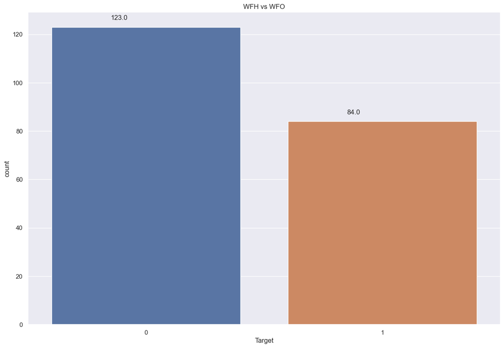

```python
# Histogram of proportion of people who work from home compared to the people who work in office
# the Target feature column gives a rank of 0.0 would rather stay home and 1.0 of would rather go back to the office

# creating the histogram
ax=sns.countplot(x='Target', data=data_cleaned)
plt.title("WFH vs WFO")
for p in ax.patches:
    ax.annotate('{:}'.format(p.get_height()), (p.get_x()+0.25, p.get_height()+3))
```

I am also going to look at how many males and how many females are in the data set to see if the data is balanced. Having balanced data is important for supervised learning model analysis. Unbalanced data can create errors or inconsistencies.

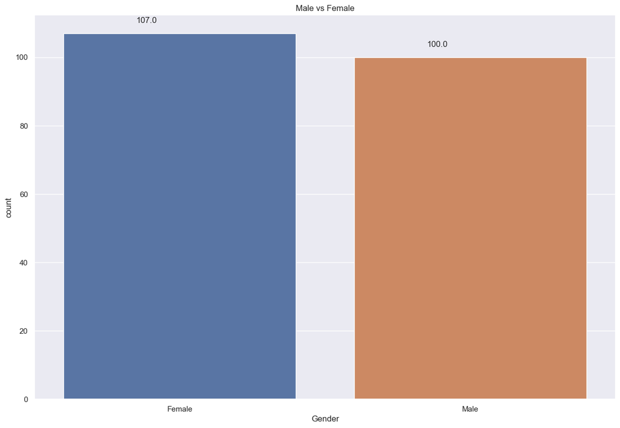

```python
ax=sns.countplot(x="Gender", data=data_cleaned)
plt.title('Male vs Female')
for p in ax.patches:
    ax.annotate('{:}'.format(p.get_height()), (p.get_x()+0.25, p.get_height()+3))
```

This data seems to be balanced between male and female with 100 males and 107 females surveyed.

```python
data_cleaned.head(5)
```

|  | ID | Name | Age | Occupation | Gender | RM_save_money | RM_quality_time | RM_better_sleep | RM_professional_growth | RM_lazy | RM_productive | RM_better_work_life_balance | Target |
| --- | --- | --- | --- | --- | --- | --- | --- | --- | --- | --- | --- | --- | --- |
| 0 | 1 | Bhavana | 45 | Tutor | Female | Yes | Yes | Yes | 5 | 1 | 5 | 5 | 1 |
| 1 | 2 | Harry | 24 | Tutor | Male | No | No | No | 2 | 2 | 2 | 3 | 1 |
| 2 | 3 | Banditaa | 53 | HR | Female | Yes | Yes | Yes | 3 | 3 | 4 | 5 | 1 |
| 3 | 4 | Neetha | 26 | Engineer | Female | Yes | Yes | No | 3 | 4 | 4 | 4 | 0 |
| 4 | 5 | Ram | 26 | Recruiter | Male | No | Yes | No | 3 | 3 | 5 | 4 | 1 |

This is a bit of the data to see where we are at in terms of data cleaning and exploratory data analysis. The number values range from 1-5 for RM_professional_growth, RM_lazy, RM_productive, and RM_better_work_life_balance. A rating of 5 is the highest value, for example a productive rating of 5 means the feel the most productive working from home. A rating of 1 in this category means that they do not feel they are productive while working from home.

I am going to look at a graph that lets us visualize how people view their prodtivity levels working from home compared to working in person.

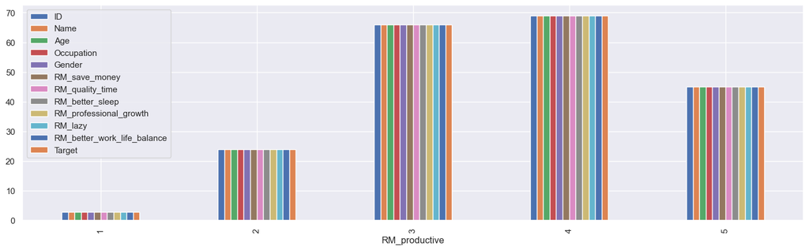

```python
ax = data_cleaned.groupby(["RM_productive"]).count().plot.bar(figsize=(18,5))
```

Most people said that work from home made them more productive giving a rank of 4. There are a lot of people that have ratings of 3 and 5 as well. This shows us that the majority of people feel they are more productive when they work from home compared to working in the office.

Another interesting and useful attribute that I can look at is the distribution of occupations in this data set. Do certain jobs like to work from home more than others? This data set only contains jobs that are able to work from home, for example, a nurse or firefighter will not be included in this data set.

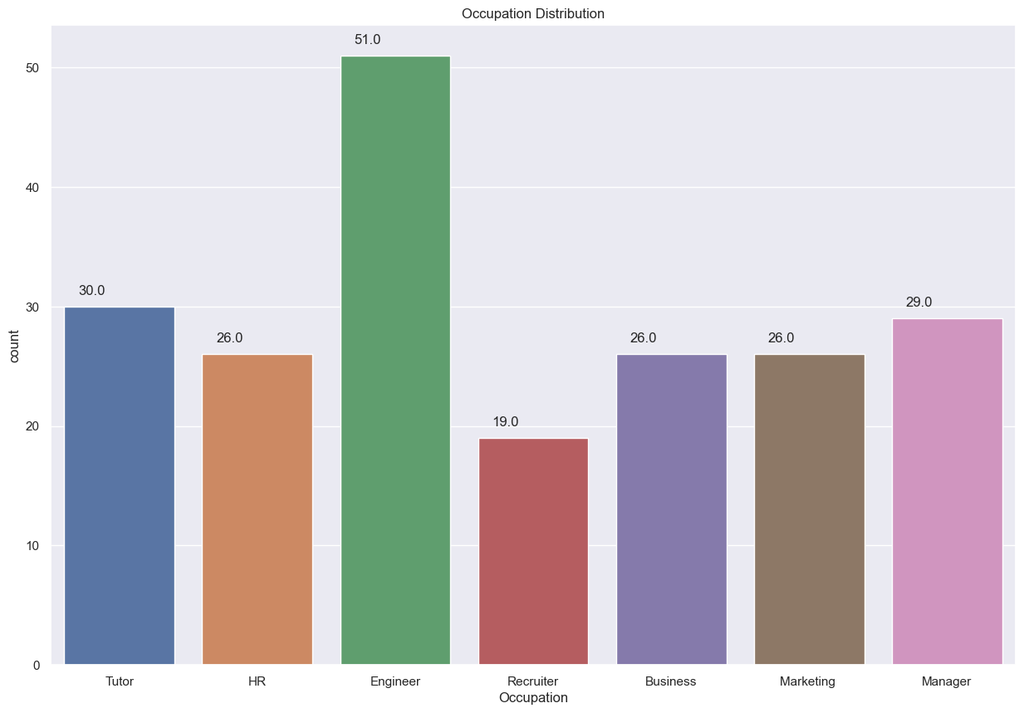

```python
# bar chart of occupation
ax = sns.countplot(x='Occupation', data=data_cleaned)
plt.title("Occupation Distribution")
for p in ax.patches:
    ax.annotate('{:}'.format(p.get_height()), (p.get_x()+0.1, p.get_height()+1))
```

This graphic shows that a large proporiton of the occupations are engineers. This could skew data analysis due to different personalities of individuals being more or less likely to work from home. I will be sure to include this in my data discussion.

I am going to create another correlation matrix after I did my data cleaning for the exploratory data analysis

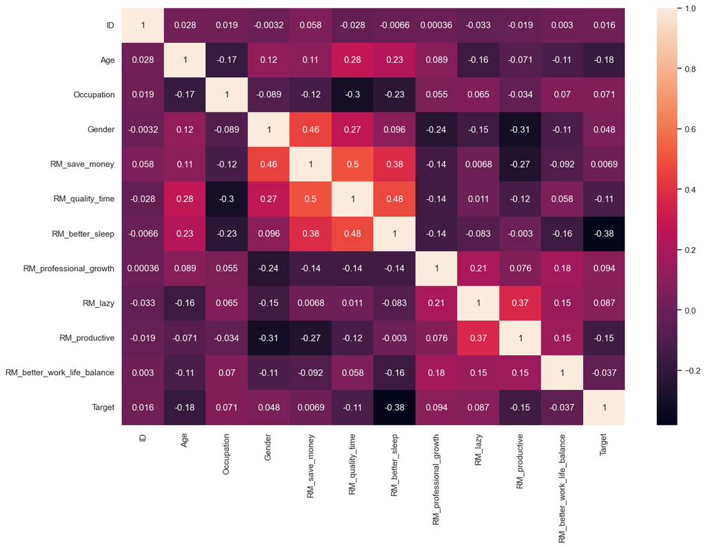

```python
# correlation matrix
correlation = ['Occupation', 'Gender', 'RM_save_money', 'RM_quality_time',
              'RM_better_sleep', "RM_professional_growth", "RM_lazy", "RM_productive", "RM_better_work_life_balance", "Target"]

for i in correlation:
    unique_values=data_cleaned[i].unique()
    data_cleaned.replace(to_replace=unique_values,
                             value=list(range(len(unique_values))), inplace=True)

corrMatrix = data_cleaned.corr()
sns.set(rc = {'figure.figsize': (15,10)})
sns.heatmap(corrMatrix, annot=True)
plt.show()
```

Looking at this cleaned data set correlation matrix the highest correlation is 0.5 between the rating of saving money and the rating of quaility time. These two features shouldn't be inherently correlated but since it is such a small value and it doesn't denote any high correlation I should not have to worry about feature collinearity and it affecting my data modeling. I discussed how collinearity can affect data modeling in the data cleaning portion.

# Modeling

## Logistic Regresion

Step 1: map data into 1 for yes and 0 for no so that logistic regression can perform correctly. Also mapping the categorical data variables to 1 and 0.

```python
# mapping gender to 0 for not a male and 1 for yes a male
gender = pd.get_dummies(data_cleaned['Gender'], drop_first=True)
gender.head()
```

|  | Male |
| --- | --- |
| 0 | 0 |
| 1 | 1 |
| 2 | 0 |
| 3 | 0 |
| 4 | 1 |

```python
# adding this new variable for gender into the data set
data_mapped=pd.concat([data_cleaned,gender],axis=1)
# dropping the previous gender column
data_mapped.drop(['Gender'],axis=1,inplace=True)

data_mapped.head()
```

|  | ID | Name | Age | Occupation | RM_save_money | RM_quality_time | RM_better_sleep | RM_professional_growth | RM_lazy | RM_productive | RM_better_work_life_balance | Target | Male |
| --- | --- | --- | --- | --- | --- | --- | --- | --- | --- | --- | --- | --- | --- |
| 0 | 1 | Bhavana | 45 | Tutor | Yes | Yes | Yes | 5 | 1 | 5 | 5 | 1 | 0 |
| 1 | 2 | Harry | 24 | Tutor | No | No | No | 2 | 2 | 2 | 3 | 1 | 1 |
| 2 | 3 | Banditaa | 53 | HR | Yes | Yes | Yes | 3 | 3 | 4 | 5 | 1 | 0 |
| 3 | 4 | Neetha | 26 | Engineer | Yes | Yes | No | 3 | 4 | 4 | 4 | 0 | 0 |
| 4 | 5 | Ram | 26 | Recruiter | No | Yes | No | 3 | 3 | 5 | 4 | 1 | 1 |

Gender is now in the format I need for logistical regression. Yes Male=1, No Male=0. Now I can map the yes and no values to 0 or 1

```python
# mapping the yes and no columns to 1 and 0.
# categorical variable columns with yes or no values
categorical = ["RM_save_money", "RM_quality_time", "RM_better_sleep"]

# changing yes to 1 and no to 0
def binary_map(x):
    return x.map({'Yes': 1, 'No': 0, np.nan: -1, 'Unknown': -1})

# replace the values in my data set to 1 and 0
data_mapped[categorical]=data_mapped[categorical].apply(binary_map)

# visualize outcome
data_mapped.head()
```

|  | ID | Name | Age | Occupation | RM_save_money | RM_quality_time | RM_better_sleep | RM_professional_growth | RM_lazy | RM_productive | RM_better_work_life_balance | Target | Male |
| --- | --- | --- | --- | --- | --- | --- | --- | --- | --- | --- | --- | --- | --- |
| 0 | 1 | Bhavana | 45 | Tutor | 1 | 1 | 1 | 5 | 1 | 5 | 5 | 1 | 0 |
| 1 | 2 | Harry | 24 | Tutor | 0 | 0 | 0 | 2 | 2 | 2 | 3 | 1 | 1 |
| 2 | 3 | Banditaa | 53 | HR | 1 | 1 | 1 | 3 | 3 | 4 | 5 | 1 | 0 |
| 3 | 4 | Neetha | 26 | Engineer | 1 | 1 | 0 | 3 | 4 | 4 | 4 | 0 | 0 |
| 4 | 5 | Ram | 26 | Recruiter | 0 | 1 | 0 | 3 | 3 | 5 | 4 | 1 | 1 |

```python
# checking data types to make sure they are what I need them to be
data_mapped.dtypes
```

```
ID                              int64
Name                           object
Age                             int64
Occupation                     object
RM_save_money                   int64
RM_quality_time                 int64
RM_better_sleep                 int64
RM_professional_growth          int64
RM_lazy                         int64
RM_productive                   int64
RM_better_work_life_balance     int64
Target                          int64
Male                            uint8
dtype: object
```

The data types are correct. They are integers which is the necessary data type for logistic regression

Now that the yes and no values are mapped to numerical values of 0 and 1 we can move on to step 2.

Step 2: split the data into training and test sets which is necessary to perform data modeling and classification on a singular data set

```python
# need to create an x value of columns and a y value of target from the data set

X = data_mapped[["Age", 'RM_save_money', "RM_quality_time", "RM_better_sleep",
               "RM_professional_growth", "RM_lazy", "RM_productive", "RM_better_work_life_balance", "Male"]]

y = data_mapped["Target"]

# visualizing data
print(X)
print(y)
```

```
     Age  RM_save_money  RM_quality_time  RM_better_sleep  \
0     45              1                1                1
1     24              0                0                0
2     53              1                1                1
3     26              1                1                0
4     26              0                1                0
..   ...            ...              ...              ...
202   32              1                1                1
203   52              1                1                1
204   22              1                1                0
205   25              1                0                0
206   23              1                1                1

     RM_professional_growth  RM_lazy  RM_productive  \
0                         5        1              5
```

[output cut: 37 more lines]

```python
# train and test set
# setting a random seed so data can have the same values
np.random.seed(110)

# splitting the data
X_train, X_test, y_train, y_test = train_test_split(X, y, train_size = 0.8, test_size = 0.2, random_state = 42)

# visualizing data to see if split was implemented correctly
print(len(X_train))
print(len(X_test))
```

```
165
42
```

Step 3: Train the Logistic Regression Model

```python
# train the model on training data

model = LogisticRegression()
model.fit(X_train, y_train)
```

```
LogisticRegression()
```

Step 4: use the trained model to predict on test data

```python
# classification/prediction

pred = model.predict(X_test)
```

Based on the usage of logistic regression it seems to fit this data set the best. But, since logistic regression has no hyperparameters I am going to also create a k-nearest neighbors model and see which one performs the best in the results and analysis section.

## K-nearest neighbors

I am going to be looking at hyperparameters of n_neighbor value to determine how many k-neighbors produces the best accuracy for the model.

I am going to first create a grid search to see which hyperparameters create the best performance for my knn model. This is a way to perform cross-validation for regularization of my model.

```python
knn=KNeighborsClassifier()
#setting paramater values
param_grid = {
    'n_neighbors': [3, 5, 7],  # Different values of k
    'weights': ['uniform', 'distance'],  # Weighting scheme for neighbors
    'p': [1, 2]  # Distance metric (1: Manhattan, 2: Euclidean)
}

# performing grid search
grid_search = GridSearchCV(knn, param_grid, cv=5)
grid_search.fit(X_train, y_train)

# getting the best hyperparameters
best_params = grid_search.best_params_
print("Best Hyperparameters:", best_params)
```

```
Best Hyperparameters: {'n_neighbors': 3, 'p': 1, 'weights': 'distance'}
```

I will now fit my model using 3 for the value of k, Manhattan distance metric and distance weighting scheme for neighbors

```python
# creating knn model with n_neighbors=3
knn=KNeighborsClassifier(n_neighbors=3, weights='distance', p=1)
# fitting the model
knn.fit(X_train, y_train)
```

```
KNeighborsClassifier(n_neighbors=3, p=1, weights='distance')
```

```python
# making predictions with knn model
y_pred = knn.predict(X_test)
```

# Results and Analysis

I am going to check the effictiveness of both of my models and compare which is the "better" model. I am going to get the accuracy of the model, RMSE value and mean squared value and mean absolute value. I will also look at a confusion matrix to help with the results of the model. Since the data is decently balanced will not look at the ROC and AUC values for each model because looking at accuracy should suffice for a balanced model.

## Logistic Regression Results

```python
# accuracy
logreg_accuracy = accuracy_score(y_test, pred)
print("Accuracy of Logistic Regression Model:", logreg_accuracy)
```

```
Accuracy of Logistic Regression Model: 0.8095238095238095
```

```python
#MSE, RMSE, and mean absolute value metrics
print('Mean Abs value:' ,metrics.mean_absolute_error(y_test,pred))
print('Mean squared value:',metrics.mean_squared_error(y_test,pred))
print('root mean squared error value:',math.sqrt(metrics.mean_squared_error(y_test,pred)))
```

```
Mean Abs value: 0.19047619047619047
Mean squared value: 0.19047619047619047
root mean squared error value: 0.4364357804719847
```

```python
# confusion matrix
print(classification_report(y_test,pred))
print("\n")
print(confusion_matrix(y_test,pred))
```

```
              precision    recall  f1-score   support

           0       0.81      0.88      0.85        25
           1       0.80      0.71      0.75        17

    accuracy                           0.81        42
   macro avg       0.81      0.79      0.80        42
weighted avg       0.81      0.81      0.81        42



[[22  3]
 [ 5 12]]
```

## K-Nearest Neighbors Results

```python
# accuracy
knn_accuracy = accuracy_score(y_test, y_pred)
print("Accuracy of Logistic Regression Model:", knn_accuracy)
```

```
Accuracy of Logistic Regression Model: 0.9523809523809523
```

```python
#MSE, RMSE, and mean absolute value metrics
print('Mean Abs value:' ,metrics.mean_absolute_error(y_test,y_pred))
print('Mean squared value:',metrics.mean_squared_error(y_test,y_pred))
print('root mean squared error value:',math.sqrt(metrics.mean_squared_error(y_test,y_pred)))
```

```
Mean Abs value: 0.047619047619047616
Mean squared value: 0.047619047619047616
root mean squared error value: 0.21821789023599236
```

```python
# confusion matrix
print(classification_report(y_test,y_pred))
print("\n")
print(confusion_matrix(y_test,y_pred))
```

```
              precision    recall  f1-score   support

           0       0.96      0.96      0.96        25
           1       0.94      0.94      0.94        17

    accuracy                           0.95        42
   macro avg       0.95      0.95      0.95        42
weighted avg       0.95      0.95      0.95        42



[[24  1]
 [ 1 16]]
```

## Summary of Results

The k-nearest neighbors model performed better than the logistic regression model in all measured metrics. The k-nearest neighbors had a model accuracy of about 95% where as the logistic regression model had an accuracy of about 81%. For RMSE, MSE and mean absolute error the k-nearest neighbors model had lower error for all of these values indicating there is less error in the model compared to the logistic regression model, another measure of better performance.

The k-nearest neighbors model also had a higher precision value, recall value and f1-score. In all data metrics the k-nearest neighbors model performs better than the logistic regression model.

## Visualization of Results

I am going to create visualization to compare some of the results that I found and to compare the models.

```python
# visualizing actual vs prediction for each model
df_logreg=pd.DataFrame({'actual':y_test,'Predicted':pred})
df_knn=pd.DataFrame({'actual':y_test, 'Predicted':pred})

combined_df=pd.concat([df_logreg, df_knn], axis=1)
print(combined_df.head(10))
```

```
     actual  Predicted  actual  Predicted
161       0          0       0          0
15        1          1       1          1
73        1          1       1          1
96        1          1       1          1
166       0          0       0          0
9         1          1       1          1
100       0          0       0          0
135       0          1       0          1
18        0          1       0          1
148       0          0       0          0
```

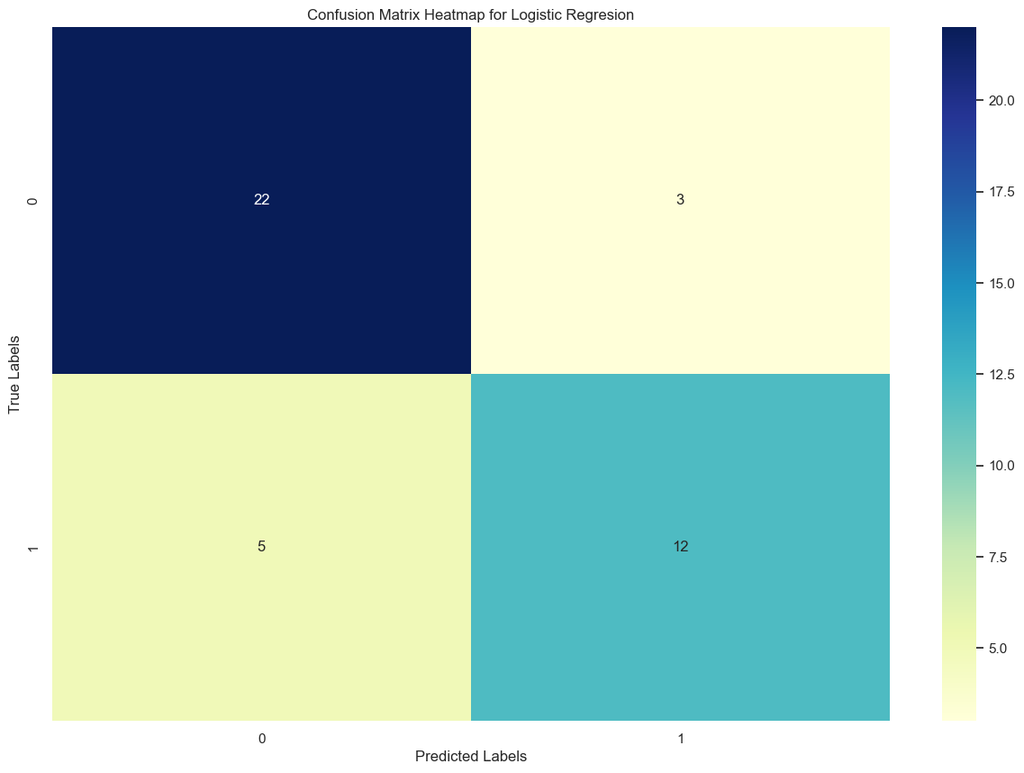

```python
# heat map visualization for logistic regression model
cm_logreg=confusion_matrix(y_test, pred)
sns.heatmap(cm_logreg, annot=True, cmap="YlGnBu")
plt.xlabel("Predicted Labels")
plt.ylabel("True Labels")
plt.title("Confusion Matrix Heatmap for Logistic Regresion")
plt.show()
```

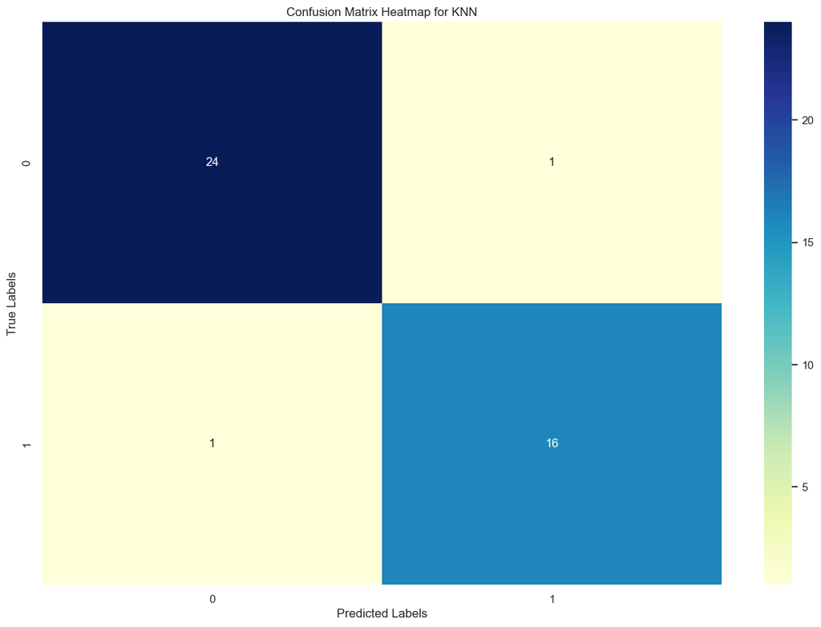

```python
# heat map visualization for k-nearest neighbors model
cm_knn=confusion_matrix(y_test, y_pred)
sns.heatmap(cm_knn, annot=True, cmap="YlGnBu")
plt.xlabel("Predicted Labels")
plt.ylabel("True Labels")
plt.title("Confusion Matrix Heatmap for KNN")
plt.show()
```

This confusion matrix is a visualization that reitterates how much better the k-nearest neighbors model performs in comparison to the logistic regression model.

```python
import altair as alt
import pandas as pd
```

Professional Growth is a factor that is very important to a lot of individuals in their job. I wanted to look at how these individuals viewed how working from home has effected this. The majority of individuals, no matter their occupation, rated professional growth a 3.0 which means average. This is somewhat saying how their professional growth has not been benefitted or harmed from working at home.

```python
alt.Chart(data_cleaned).mark_bar().encode(
    x="RM_professional_growth", y="Target", color="Occupation")
```

[interactive chart not shown]

Another Visualization I wanted to look at was if people thought working from home iproves their quailty time with friends and family outside of work and the majority of inidviduals, especially older individuals said that this was the case. This may be due to older individuals being more likely to have kids or having to work longer hours, so working from home can help improve this quaility time metric.

```python
alt.Chart(data_cleaned).mark_bar().encode(
    x="RM_quality_time", y="Target", color="Age")
```

[interactive chart not shown]

# Discussion and Conclusion

1. Learnings/Takeaways Throughout this project I learned the importance of creating multiple models with multiple parameters. My original plan was to just do a logistic regression model because it the baseline model for binary classification. After performing a k-nearest neighbors model and using a cross validation to determine the best hyperparameters I found that the k-nearest neighbors model performed significantly better.

I discussed a lot of the results throughout data cleaning, EDA, and modeling. The data cleaning took more time than anticipated, everytime I thought I had the data clean and error would occur and I realized I needed to go back and add more to the cleaning. I tried to do the machine learning modeling without converting my data types into int and the 'Yes' and 'No' of the binary classifiers to map to 1 and 0. Without this the model would not have created any results.

1. Why somethings didn't work The modeling I used worked decently well but one could argue that the logistic regression model did not have a high enough accuracy score at about 81% which is a lot of missclassifications for a data set this size to say it performed well.
1. Suggested Improvements I would try out different machine learning models like a Decision Tree or Support Vector Machines (SVM) to see if these would have a better performance than k-nearest neighnbors. Also including more of the attributes in the model not just ones I found of interest could improve the accuracy of the model or more so the interpretation of the results.